# Rapport Statistique

2024-10-12

## Introduction :

Ce rapport présente une étude statistique approfondie portant sur les logements du département du Rhône (69). En s’appuyant sur un ensemble de données assez variées, comprenant des informations telles que le type de logement (neuf ou ancien), la consommation énergétique totale, la consommation par mètre carré ou encore la surface habitable du logement, l’objectif de cette analyse est de répondre à plusieurs problématiques liées à la performance énergétique des logements.  
L’étiquette DPE (Diagnostic de Performance Énergétique) est souvent considérée comme un indicateur principal de la consommation d’énergie d’un bien immobilier. Dans cette étude, nous allons donc montrer que l’étiquette DPE est un réel indicateur pour la consommation énergétique. Cependant, nous cherchons aussi à aller au-delà de cette simple évaluation en explorant d’autres facteurs qui pourraient potentiellement influencer la consommation énergétique des logements. À l’aide de diverses visualisations et analyses comparatives, nous examinerons si des paramètres tels que l’ancienneté du bâtiment, la surface, ou encore le type d’habitat (appartement ou maison) ont un impact significatif sur la consommation énergétique, et comment ces variables interagissent entre elles.

## Paramètres choisis pour ce rapport :

Code postal : tous  
Type de logement : les deux comparés

## Présentation des données :

Dans ce jeu de donnée, il y à 410194 logements ancien et 33244 logements neufs.

La moyenne de consommation énergétique par m² des logements neufs est de : 76.82 kWh/m²/n et celle des logements anciens est de : 241.64 kWh/m²/n.

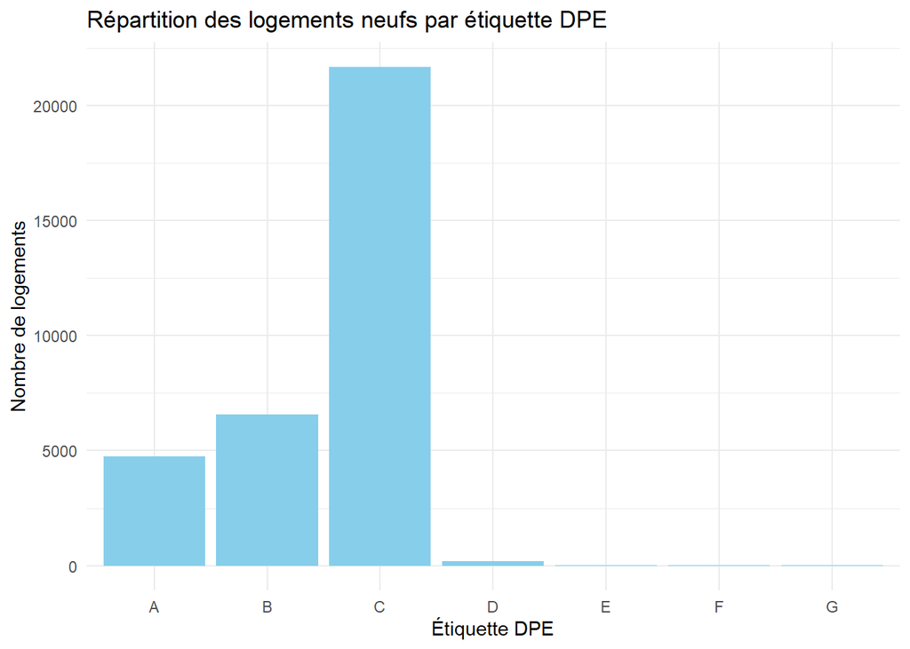

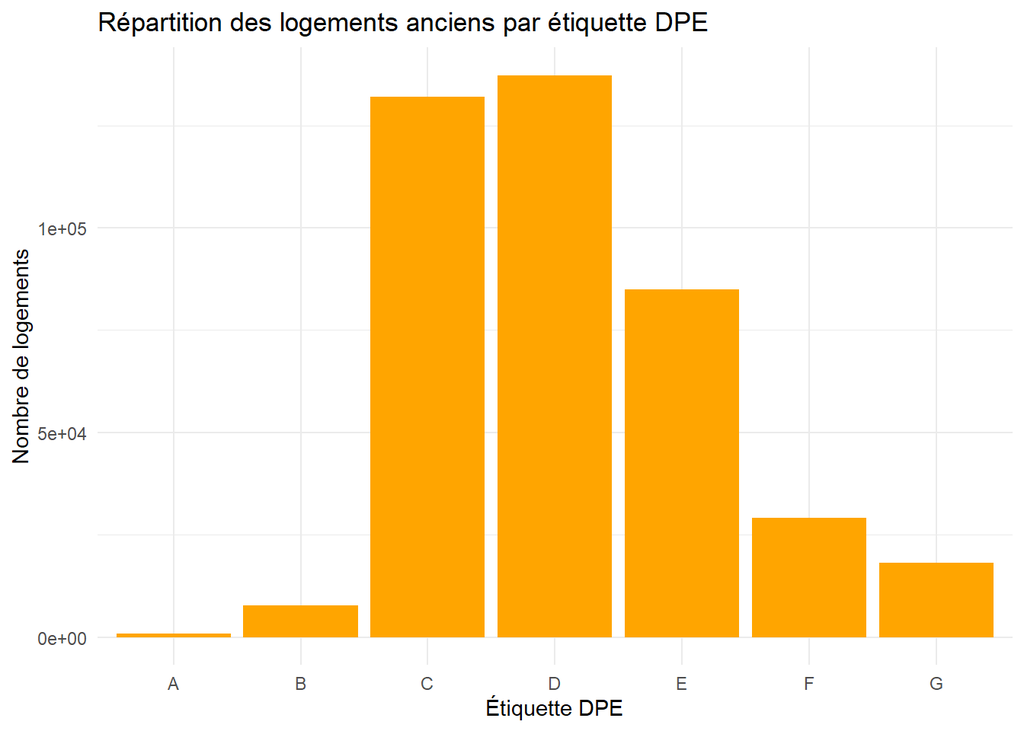

L’étiquette DPE la plus représentée pour les **logements anciens** est la D .  
Pour les **logements neufs**, l’étiquette la plus représentée est la C .  
Cela montre que les logements anciens et neufs ne présentent pas la même distribution, en globalité, les logements neufs présentent des étiquettes DPE plus faible que les logements anciens.

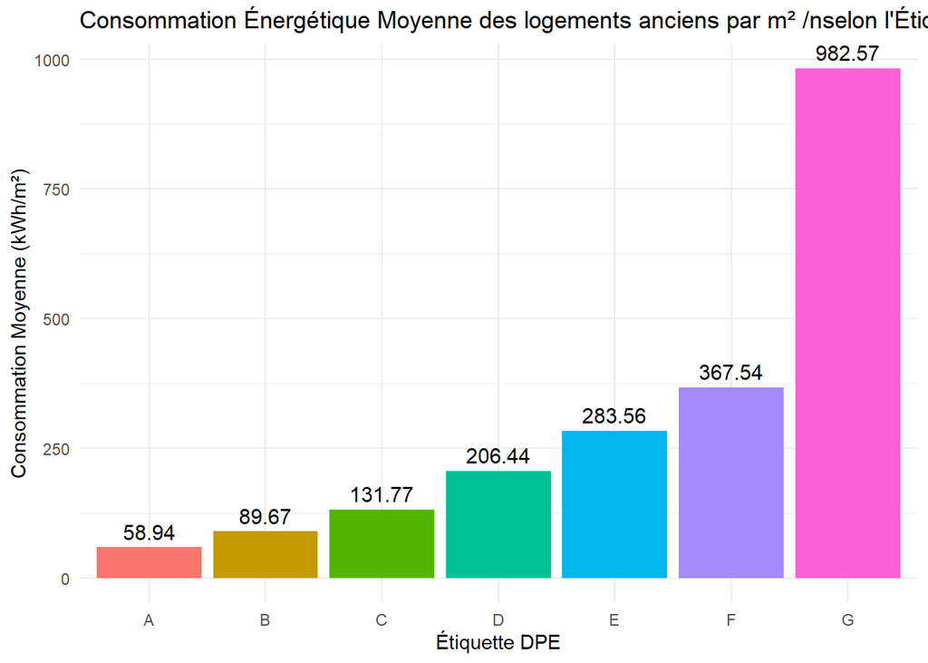

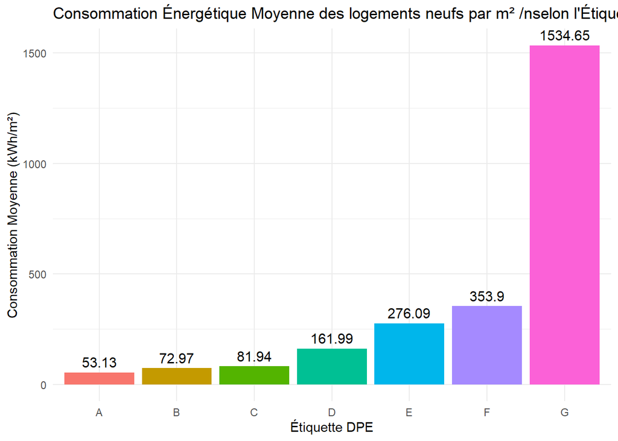

Écart Type de la Consommation par Étiquette DPE (logements neufs et anciens)

| Étiquette DPE | Écart Type (neuf) | Écart Type (ancien) |
| --- | --- | --- |
| A | 10.71 | 8.96 |
| B | 16.51 | 15.95 |
| C | 22.31 | 31.01 |
| D | 51.80 | 29.71 |
| E | 22.73 | 31.65 |
| F | 13.95 | 42.63 |
| G | 1539.58 | 40486.06 |

Pour les **logements neufs**, l’étiquette DPE avec l’écart-type le plus élevé est la G avec un écart-type de 1539.58 , tandis que l’étiquette avec l’écart-type le plus faible est la A avec 10.71 .  
Pour les **logements anciens**, l’étiquette DPE avec l’écart-type le plus élevé est la G avec un écart-type de 40486.06 , tandis que l’étiquette avec l’écart-type le plus faible est la A avec 8.96 .  
En comparant les deux types de logements, on constate que l’écart-type de la consommation pour les logements neufs et anciens est plutôt similaire, hormis pour l’étiquette DPE G . En effet, l’écart-type des logements anciens pour l’étiquette DPE G est largement supérieurs à celui des logements neufs ce qui amène à se questionner sur la variabilité des performances énergétiques des bâtiments anciens et la potentielle influence de facteurs tels que l’année de construction, la qualité des matériaux utilisés ou encore l’absence de rénovations énergétiques.

Pour ces paramètres, le graphique sur la **Répartition de la Consommation Moyenne par Période de Construction** n’est pas pertinent.

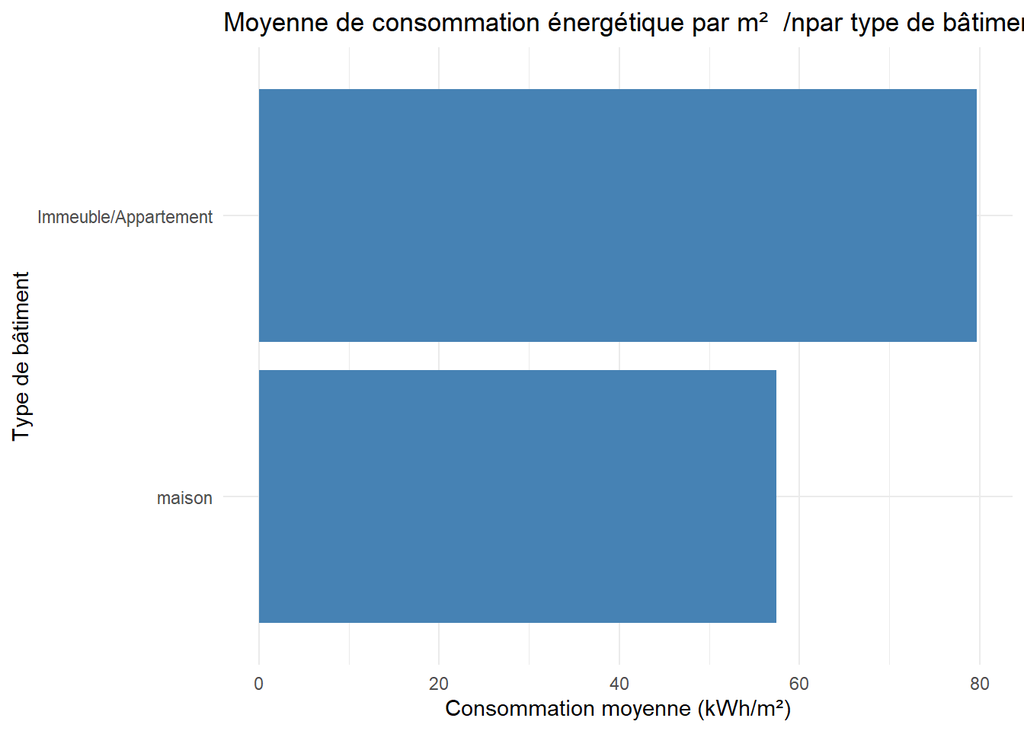

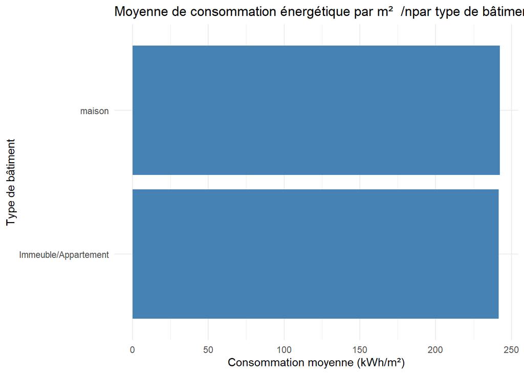

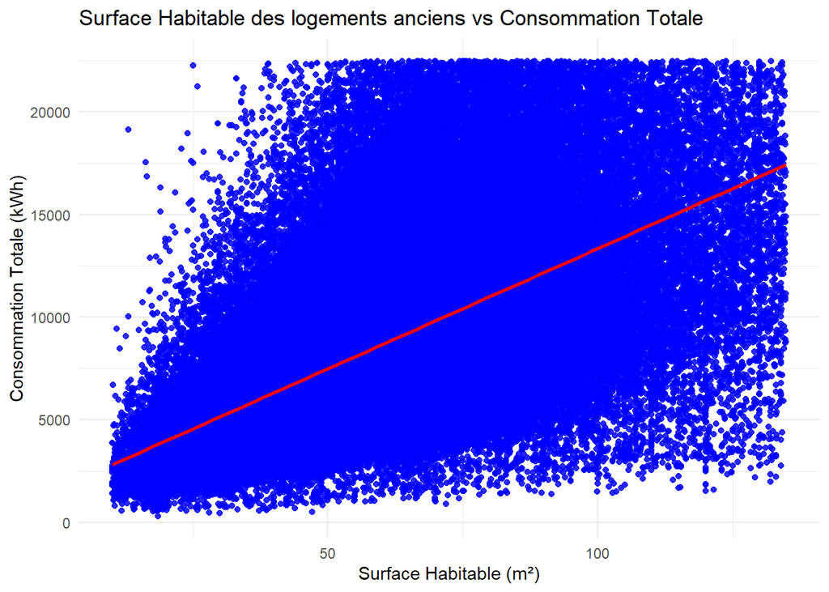

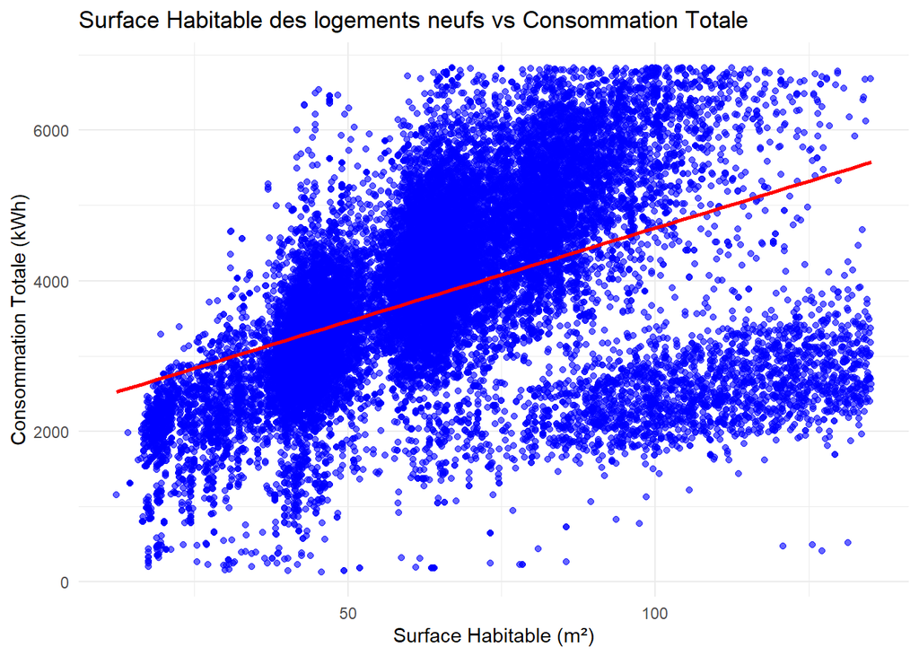

Pour le graphique : **Surface Habitable des logements anciens vs Consommation Totale**  
- **Corrélation** entre la surface habitable et la consommation totale : 0.58  
- **Pente de la régression** : 117.18  
- **Interception** : 1625.31  
- **p-value de la pente** : < 2.2e-16  
- Il existe une relation positive significative entre la surface habitable et la consommation énergétique. Cela signifie que lorsque la surface augmente, la consommation tend également à augmenter.  
/n/nPour le graphique : **Surface Habitable des logements neufs vs Consommation Totale**  
- **Corrélation** entre la surface habitable et la consommation totale : 0.47  
- **Pente de la régression** : 24.85  
- **Interception** : 2216.21  
- **p-value de la pente** : < 2.2e-16  
- Il existe une relation positive significative entre la surface habitable et la consommation énergétique. Cela signifie que lorsque la surface augmente, la consommation tend également à augmenter.